# 21_Homework 3

```r
library(fpp3)
```

# Session 21 - Homework 3

For this exercise use the quarterly number of arrivals to Australia from New Zealand, 1981 Q1 – 2012 Q3, from data set `aus_arrivals`.

```r
nz_arrivals <- aus_arrivals %>% filter(Origin == "NZ")
nz_arrivals
```

```
# A tsibble: 127 x 3 [1Q]
# Key:       Origin [1]
   Quarter Origin Arrivals
     <qtr> <chr>     <int>
 1 1981 Q1 NZ        49140
 2 1981 Q2 NZ        87467
 3 1981 Q3 NZ        85841
 4 1981 Q4 NZ        61882
 5 1982 Q1 NZ        42045
 6 1982 Q2 NZ        63081
 7 1982 Q3 NZ        73275
 8 1982 Q4 NZ        54808
 9 1983 Q1 NZ        41030
10 1983 Q2 NZ        56155
# ... with 117 more rows
```

1. Make a time plot of your data adjusting the grid to properly identify a yearly seasonality.

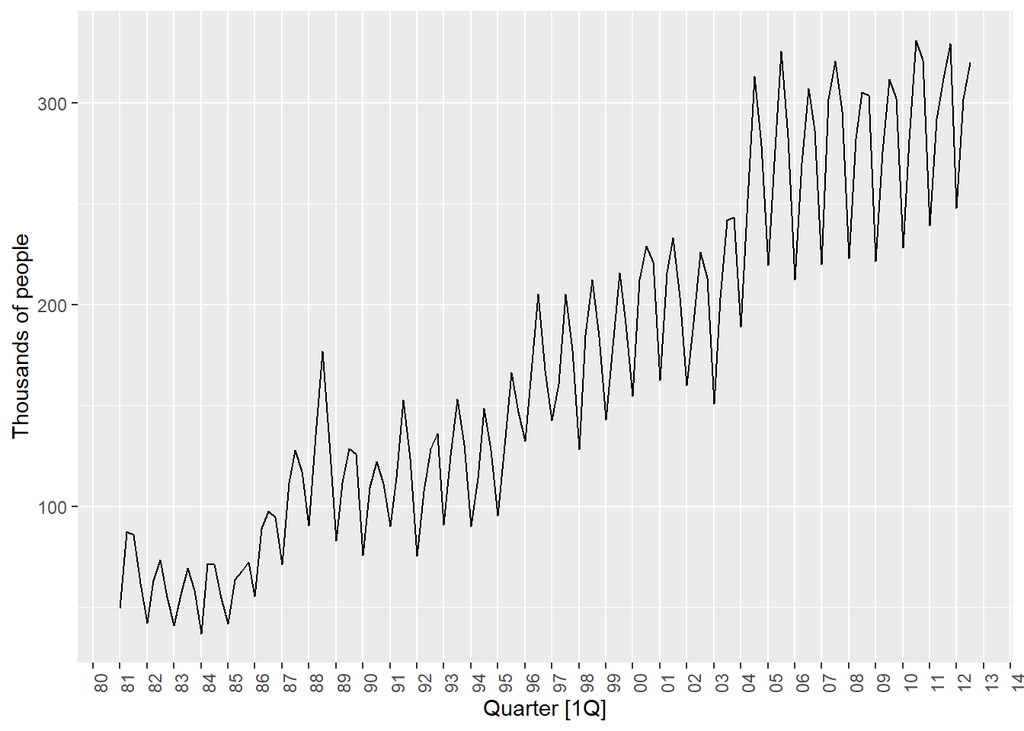

```r
nz_arrivals %>%
  autoplot(Arrivals / 1e3) +
  scale_x_yearmonth(date_breaks = "1 year",
                  date_minor_breaks = "1 year",
                  date_labels = "%y") +
  theme(axis.text.x = element_text(angle = 90)) +
  labs(y = "Thousands of people")
```

2. Create a training set that withholds the last two years of available data. Forecast the test set using an appropriate model for Holt-Winters’ multiplicative method.

```r
nz_tr <- nz_arrivals %>%
  slice(1:(n() - 8))

fit <- nz_tr %>%
  model(ETS(Arrivals ~ error("M") + trend("A") + season("M")))
```

```r
fc <- fit  %>%
  forecast(h = "2 years")
```

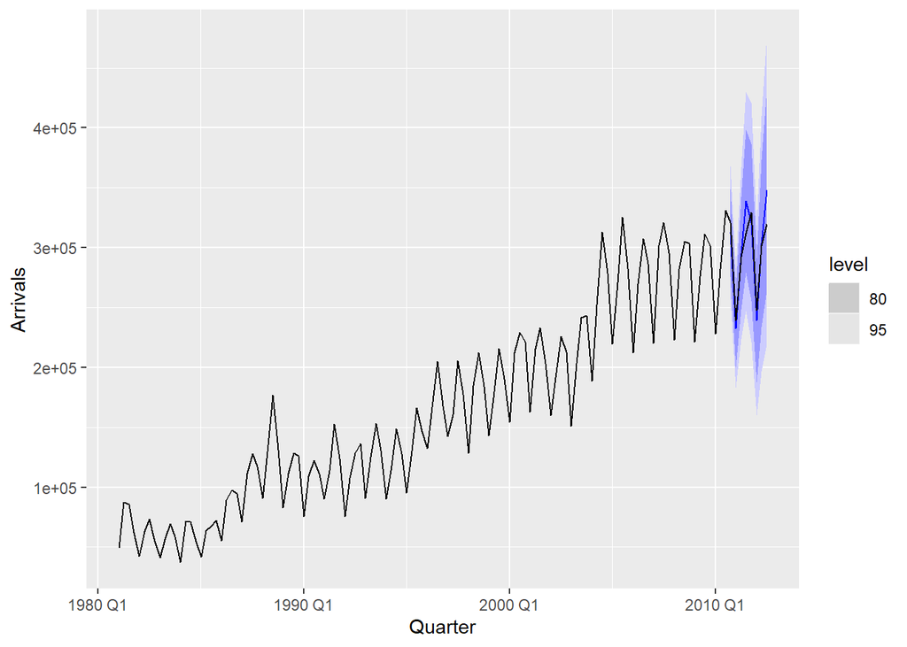

```r
fc %>%
  autoplot() +
  autolayer(nz_arrivals, Arrivals)
```

3. Would you say that multiplicative seasonality is necessary?

The multiplicative seasonality is important in this example because seasonal pattern increases in size proportionally to the level of the trend

4. Perform forecasts of up to a horizon of two years using the following models:
- an ETS model;
- an additive ETS model applied to a log transformed series;
- a Seasonal Naïve method;
- an STL decomposition applied to the log transformed data followed by an ETS model applied to the seasonally adjusted (transformed) data.

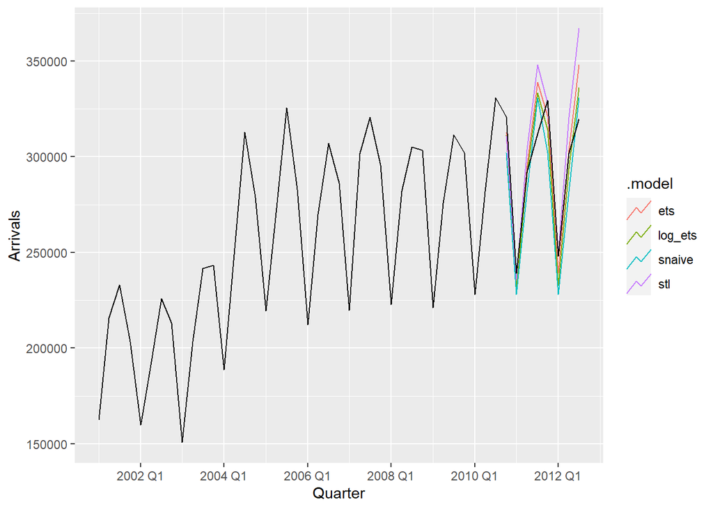

```r
fit <- nz_tr %>%
  model(
    ets = ETS(Arrivals),
    log_ets = ETS(log(Arrivals)),
    snaive = SNAIVE(Arrivals),
    stl = decomposition_model(STL(log(Arrivals)), ETS(season_adjust))
  )

fc <- fit %>%
        forecast(h = "2 years")

fc %>%
  autoplot(level = NULL) +
  autolayer(filter(nz_arrivals, year(Quarter) > 2000), Arrivals)
```

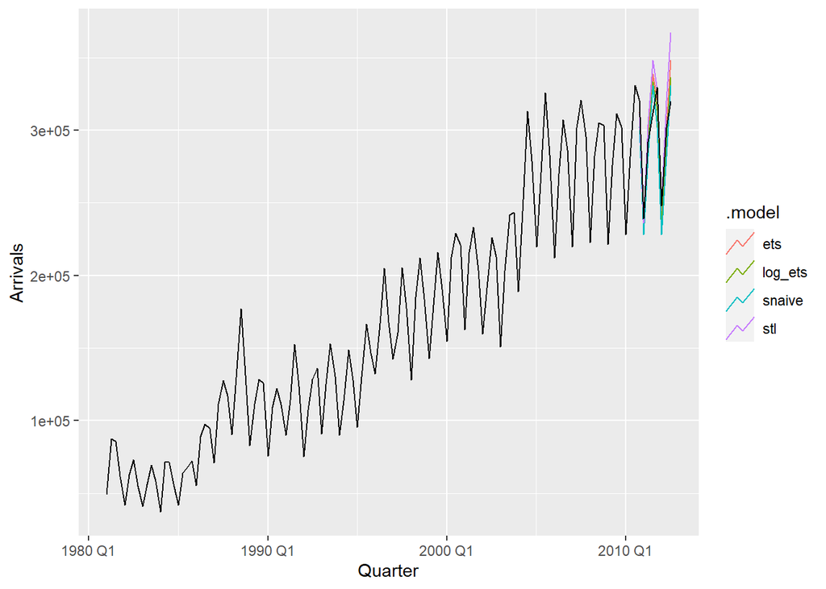

```r
fc %>%
  autoplot(level = NULL) +
  autolayer(nz_arrivals, Arrivals)
```

5. Which method gives the best forecasts for a horizon h = 1? and for a horizon of h = 8?

```r
fc <- fc %>%
        group_by(.model) %>%
        mutate(h = row_number()) %>%
        ungroup() %>%
        as_fable(response = "Arrivals", distribution = Arrivals)

fc
```

```
# A fable: 32 x 6 [1Q]
# Key:     Origin, .model [4]
   Origin .model  Quarter           Arrivals   .mean     h
   <chr>  <chr>     <qtr>             <dist>   <dbl> <int>
 1 NZ     ets     2010 Q4   N(312454, 8e+08) 312454.     1
 2 NZ     ets     2011 Q1 N(232812, 6.4e+08) 232812.     2
 3 NZ     ets     2011 Q2  N(3e+05, 1.3e+09) 295263.     3
 4 NZ     ets     2011 Q3 N(338773, 2.2e+09) 338773.     4
 5 NZ     ets     2011 Q4 N(321156, 2.6e+09) 321156.     5
 6 NZ     ets     2012 Q1 N(239255, 1.6e+09) 239255.     6
 7 NZ     ets     2012 Q2    N(3e+05, 3e+09) 303383.     7
 8 NZ     ets     2012 Q3 N(348031, 4.3e+09) 348031.     8
 9 NZ     log_ets 2010 Q4    t(N(13, 0.008)) 311131.     1
10 NZ     log_ets 2011 Q1    t(N(12, 0.012)) 230805.     2
# ... with 22 more rows
```

```r
fc %>%
  accuracy(nz_arrivals, by = c("h", ".model")) %>%
  arrange(h, RMSE)
```

[output not shown]

[output cut: 40 more lines]

[output not shown]

```
# A tibble: 32 x 11
       h .model  .type     ME   RMSE    MAE    MPE  MAPE   MASE  RMSSE  ACF1
   <int> <chr>   <chr>  <dbl>  <dbl>  <dbl>  <dbl> <dbl>  <dbl>  <dbl> <dbl>
 1     1 ets     Test   8443.  8443.  8443.  2.63  2.63  0.567  0.436     NA
 2     1 log_ets Test   9766.  9766.  9766.  3.04  3.04  0.656  0.505     NA
 3     1 stl     Test  10025. 10025. 10025.  3.12  3.12  0.674  0.518     NA
 4     1 snaive  Test  18914  18914  18914   5.89  5.89  1.27   0.977     NA
 5     2 stl     Test   2976.  2976.  2976.  1.24  1.24  0.200  0.154     NA
 6     2 ets     Test   6291.  6291.  6291.  2.63  2.63  0.422  0.325     NA
 7     2 log_ets Test   8298.  8298.  8298.  3.47  3.47  0.556  0.429     NA
 8     2 snaive  Test  10941  10941  10941   4.58  4.58  0.734  0.565     NA
 9     3 log_ets Test    744.   744.   744.  0.255 0.255 0.0500 0.0386    NA
10     3 ets     Test  -3191.  3191.  3191. -1.09  1.09  0.214  0.165     NA
# ... with 22 more rows
```

Best model on average

```r
fc %>%
  accuracy(nz_arrivals) %>%
  arrange(RMSE)
```

```
# A tibble: 4 x 11
  .model  Origin .type      ME   RMSE    MAE    MPE  MAPE  MASE RMSSE    ACF1
  <chr>   <chr>  <chr>   <dbl>  <dbl>  <dbl>  <dbl> <dbl> <dbl> <dbl>   <dbl>
1 log_ets NZ     Test    2467. 13342. 11904.  1.03   4.03 0.800 0.689 -0.0786
2 ets     NZ     Test   -3495. 14913. 11421. -0.964  3.78 0.768 0.771 -0.0260
3 snaive  NZ     Test    9709. 18051. 17156.  3.44   5.80 1.15  0.933 -0.239
4 stl     NZ     Test  -12535. 22723. 16172. -4.02   5.23 1.09  1.17   0.109
```

6. Does the method pass the residuals test?

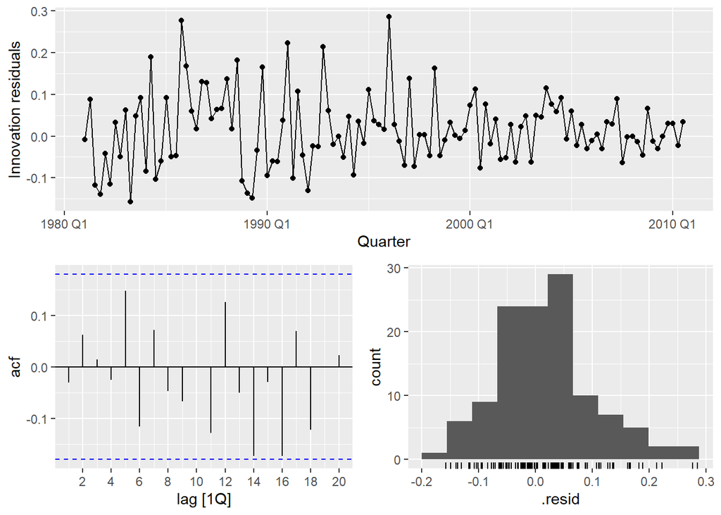

```r
fit %>% select(log_ets) %>% gg_tsresiduals()
```

```r
fit %>%
  select(log_ets) %>%
  augment() %>%
  features(.innov, ljung_box, lag = 12, dof = 6)
```

```
# A tibble: 1 x 3
  .model  lb_stat lb_pvalue
  <chr>     <dbl>     <dbl>
1 log_ets    11.0    0.0887
```

The best method is the ETS model on the logged data (based on RMSE), and it passes the residuals tests.

7. Compare the same four methods using time series cross-validation instead of using a training and test set. Do you come to the same conclusions?. The smallest dataset shall include 10 years of available data and the datasets shall increase in steps of 1 year.

Create the cv datasets

```r
nz_cv <- nz_arrivals %>%
  stretch_tsibble(.init = 10, .step = 1)
```

```r
nz_cv %>% pull(.id) %>% max()
```

```
[1] 118
```

118 datasets

```r
fit_cv <- nz_cv %>%
  model(
    ets = ETS(Arrivals),
    log_ets = ETS(log(Arrivals)),
    snaive = SNAIVE(Arrivals),
    stl = decomposition_model(STL(log(Arrivals)), ETS(season_adjust))
  )
```

```r
fit_cv
```

```
# A mable: 118 x 6
# Key:     .id, Origin [118]
     .id Origin          ets      log_ets   snaive                       stl
   <int> <chr>       <model>      <model>  <model>                   <model>
 1     1 NZ     <ETS(A,N,N)> <ETS(A,N,N)> <SNAIVE> <STL decomposition model>
 2     2 NZ     <ETS(A,N,N)> <ETS(M,N,N)> <SNAIVE> <STL decomposition model>
 3     3 NZ     <ETS(A,N,N)> <ETS(M,N,N)> <SNAIVE> <STL decomposition model>
 4     4 NZ     <ETS(A,N,N)> <ETS(M,N,A)> <SNAIVE> <STL decomposition model>
 5     5 NZ     <ETS(M,N,M)> <ETS(M,N,A)> <SNAIVE> <STL decomposition model>
 6     6 NZ     <ETS(M,N,M)> <ETS(A,N,A)> <SNAIVE> <STL decomposition model>
 7     7 NZ     <ETS(M,N,M)> <ETS(A,N,A)> <SNAIVE> <STL decomposition model>
 8     8 NZ     <ETS(M,N,M)> <ETS(M,N,A)> <SNAIVE> <STL decomposition model>
 9     9 NZ     <ETS(M,N,M)> <ETS(M,N,A)> <SNAIVE> <STL decomposition model>
10    10 NZ     <ETS(M,N,M)> <ETS(M,N,A)> <SNAIVE> <STL decomposition model>
# ... with 108 more rows
```

```r
fc_cv <- fit_cv %>%
            forecast(h = 8)
```

```r
fc_cv <- fc_cv %>%
  group_by(.id, .model) %>%
  mutate(h = row_number()) %>%
  ungroup() %>%
  as_fable(response = "Arrivals", distribution = Arrivals)
```

```r
fc_cv %>%
  accuracy(nz_arrivals, by = c("h", ".model")) %>%
  select(h, .model, .type, MAE, RMSE, MAPE, MASE, RMSSE) %>%
  arrange(h, RMSE)
```

```
# A tibble: 32 x 8
       h .model  .type    MAE   RMSE  MAPE  MASE RMSSE
   <int> <chr>   <chr>  <dbl>  <dbl> <dbl> <dbl> <dbl>
 1     1 log_ets Test  10016. 12754.  6.97 0.683 0.672
 2     1 ets     Test  10261. 12979.  7.15 0.699 0.684
 3     1 stl     Test  10073. 12988.  6.54 0.686 0.684
 4     1 snaive  Test  14922. 19264.  9.83 1.02  1.01
 5     2 log_ets Test  11488. 14627.  8.18 0.783 0.771
 6     2 ets     Test  11906. 15112.  8.48 0.811 0.796
 7     2 stl     Test  11553. 15342.  7.64 0.787 0.808
 8     2 snaive  Test  15018. 19344.  9.87 1.02  1.02
 9     3 log_ets Test  13143. 17248.  9.04 0.896 0.909
10     3 ets     Test  13563. 17818.  9.33 0.924 0.939
# ... with 22 more rows
```

If we wanted the model that performed best on average in terms of RMSE for every horizon, we should run:

```r
fc_cv %>%
  accuracy(nz_arrivals) %>%
  select(.model, .type, MAE, RMSE, MAPE, MASE, RMSSE) %>%
  arrange(RMSE)
```

```
# A tibble: 4 x 7
  .model  .type    MAE   RMSE  MAPE  MASE RMSSE
  <chr>   <chr>  <dbl>  <dbl> <dbl> <dbl> <dbl>
1 log_ets Test  15556. 21069.  10.3  1.06  1.11
2 ets     Test  16204. 22158.  10.6  1.10  1.17
3 snaive  Test  18261. 24714.  11.4  1.24  1.30
4 stl     Test  16911. 24922.  10.9  1.15  1.31
```